# Project: Identify Customer Segments

```python
azdias_subset_1.shape
```

```
(774743, 79)
```

```python
azdias_subset_2 = azdias[azdias.index.isin(missing_row_data[missing_row_data > 9].index)]
azdias_subset_2
```

|  | ALTERSKATEGORIE_GROB | ANREDE_KZ | CJT_GESAMTTYP | FINANZ_MINIMALIST | FINANZ_SPARER | FINANZ_VORSORGER | FINANZ_ANLEGER | FINANZ_UNAUFFAELLIGER | FINANZ_HAUSBAUER | FINANZTYP | ... | PLZ8_ANTG1 | PLZ8_ANTG2 | PLZ8_ANTG3 | PLZ8_ANTG4 | PLZ8_BAUMAX | PLZ8_HHZ | PLZ8_GBZ | ARBEIT | ORTSGR_KLS9 | RELAT_AB |
| --- | --- | --- | --- | --- | --- | --- | --- | --- | --- | --- | --- | --- | --- | --- | --- | --- | --- | --- | --- | --- | --- |
| 0 | 2.0 | 1 | 2.0 | 3 | 4 | 3 | 5 | 5 | 3 | 4 | ... | NaN | NaN | NaN | NaN | NaN | NaN | NaN | NaN | NaN | NaN |
| 11 | 2.0 | 1 | 6.0 | 3 | 4 | 3 | 5 | 5 | 3 | 4 | ... | NaN | NaN | NaN | NaN | NaN | NaN | NaN | NaN | NaN | NaN |
| 14 | 3.0 | 1 | 6.0 | 3 | 4 | 3 | 5 | 5 | 3 | 4 | ... | NaN | NaN | NaN | NaN | NaN | NaN | NaN | NaN | NaN | NaN |
| 17 | 2.0 | 1 | 6.0 | 3 | 4 | 3 | 5 | 5 | 3 | 4 | ... | NaN | NaN | NaN | NaN | NaN | NaN | NaN | NaN | NaN | NaN |
| 20 | 2.0 | 2 | 4.0 | 4 | 3 | 1 | 4 | 5 | 1 | 3 | ... | NaN | NaN | NaN | NaN | NaN | NaN | NaN | 3.0 | 4.0 | 1.0 |
| 24 | 3.0 | 2 | 6.0 | 3 | 4 | 3 | 5 | 5 | 3 | 4 | ... | NaN | NaN | NaN | NaN | NaN | NaN | NaN | NaN | NaN | NaN |
| 26 | 3.0 | 1 | 3.0 | 5 | 2 | 4 | 2 | 3 | 1 | 3 | ... | NaN | NaN | NaN | NaN | NaN | NaN | NaN | 4.0 | 3.0 | 5.0 |
| 30 | 3.0 | 2 | 3.0 | 4 | 3 | 4 | 4 | 4 | 1 | 3 | ... | NaN | NaN | NaN | NaN | NaN | NaN | NaN | NaN | NaN | NaN |
| 35 | 2.0 | 2 | 2.0 | 3 | 4 | 3 | 5 | 5 | 3 | 4 | ... | NaN | NaN | NaN | NaN | NaN | NaN | NaN | NaN | NaN | NaN |
| 46 | NaN | 2 | 3.0 | 2 | 4 | 3 | 5 | 5 | 4 | 1 | ... | NaN | NaN | NaN | NaN | NaN | NaN | NaN | NaN | NaN | NaN |
| 48 | 3.0 | 2 | 6.0 | 3 | 4 | 3 | 5 | 5 | 3 | 4 | ... | NaN | NaN | NaN | NaN | NaN | NaN | NaN | NaN | NaN | NaN |
| 53 | 2.0 | 1 | 3.0 | 3 | 4 | 3 | 5 | 5 | 3 | 4 | ... | NaN | NaN | NaN | NaN | NaN | NaN | NaN | NaN | NaN | NaN |
| 54 | 3.0 | 1 | 6.0 | 3 | 4 | 3 | 5 | 5 | 3 | 4 | ... | NaN | NaN | NaN | NaN | NaN | NaN | NaN | NaN | NaN | NaN |
| 61 | 3.0 | 2 | 6.0 | 3 | 4 | 3 | 5 | 5 | 3 | 4 | ... | NaN | NaN | NaN | NaN | NaN | NaN | NaN | NaN | NaN | NaN |
| 62 | 3.0 | 1 | 4.0 | 3 | 4 | 3 | 5 | 5 | 3 | 4 | ... | NaN | NaN | NaN | NaN | NaN | NaN | NaN | NaN | NaN | NaN |
| 69 | 3.0 | 2 | 6.0 | 3 | 4 | 3 | 5 | 5 | 3 | 4 | ... | NaN | NaN | NaN | NaN | NaN | NaN | NaN | NaN | NaN | NaN |
| 75 | 3.0 | 2 | 6.0 | 3 | 4 | 3 | 5 | 5 | 3 | 4 | ... | NaN | NaN | NaN | NaN | NaN | NaN | NaN | NaN | NaN | NaN |
| 76 | 2.0 | 2 | 2.0 | 3 | 4 | 3 | 5 | 5 | 3 | 4 | ... | NaN | NaN | NaN | NaN | NaN | NaN | NaN | NaN | NaN | NaN |
| 81 | 3.0 | 2 | 5.0 | 3 | 4 | 3 | 5 | 5 | 3 | 4 | ... | NaN | NaN | NaN | NaN | NaN | NaN | NaN | NaN | NaN | NaN |
| 83 | 3.0 | 2 | 4.0 | 3 | 4 | 3 | 5 | 5 | 3 | 4 | ... | NaN | NaN | NaN | NaN | NaN | NaN | NaN | NaN | NaN | NaN |
| 90 | 1.0 | 2 | 4.0 | 2 | 5 | 3 | 5 | 5 | 4 | 1 | ... | NaN | NaN | NaN | NaN | NaN | NaN | NaN | NaN | NaN | NaN |
| 97 | 2.0 | 1 | 6.0 | 3 | 4 | 3 | 5 | 5 | 3 | 4 | ... | NaN | NaN | NaN | NaN | NaN | NaN | NaN | NaN | NaN | NaN |
| 99 | 2.0 | 2 | 6.0 | 3 | 4 | 3 | 5 | 5 | 3 | 4 | ... | NaN | NaN | NaN | NaN | NaN | NaN | NaN | NaN | NaN | NaN |
| 103 | 2.0 | 2 | 6.0 | 3 | 4 | 3 | 5 | 5 | 3 | 4 | ... | NaN | NaN | NaN | NaN | NaN | NaN | NaN | NaN | NaN | NaN |
| 106 | 2.0 | 2 | 1.0 | 3 | 4 | 3 | 5 | 5 | 3 | 4 | ... | NaN | NaN | NaN | NaN | NaN | NaN | NaN | NaN | NaN | NaN |
| 108 | 3.0 | 1 | 6.0 | 3 | 4 | 3 | 5 | 5 | 3 | 4 | ... | NaN | NaN | NaN | NaN | NaN | NaN | NaN | NaN | NaN | NaN |
| 109 | 3.0 | 2 | 4.0 | 3 | 4 | 3 | 5 | 5 | 3 | 4 | ... | NaN | NaN | NaN | NaN | NaN | NaN | NaN | NaN | NaN | NaN |
| 112 | 3.0 | 1 | 6.0 | 3 | 4 | 3 | 5 | 5 | 3 | 4 | ... | NaN | NaN | NaN | NaN | NaN | NaN | NaN | NaN | NaN | NaN |
| 133 | 1.0 | 2 | 6.0 | 3 | 4 | 3 | 5 | 5 | 3 | 4 | ... | NaN | NaN | NaN | NaN | NaN | NaN | NaN | NaN | NaN | NaN |
| 137 | 3.0 | 1 | 6.0 | 3 | 4 | 3 | 5 | 5 | 3 | 4 | ... | NaN | NaN | NaN | NaN | NaN | NaN | NaN | NaN | NaN | NaN |
| ... | ... | ... | ... | ... | ... | ... | ... | ... | ... | ... | ... | ... | ... | ... | ... | ... | ... | ... | ... | ... | ... |
| 891049 | 3.0 | 1 | 6.0 | 3 | 4 | 3 | 5 | 5 | 3 | 4 | ... | NaN | NaN | NaN | NaN | NaN | NaN | NaN | NaN | NaN | NaN |
| 891055 | 3.0 | 2 | 6.0 | 4 | 2 | 4 | 4 | 3 | 1 | 3 | ... | NaN | NaN | NaN | NaN | NaN | NaN | NaN | NaN | NaN | NaN |
| 891061 | 3.0 | 1 | 3.0 | 3 | 4 | 3 | 5 | 5 | 3 | 4 | ... | NaN | NaN | NaN | NaN | NaN | NaN | NaN | NaN | NaN | NaN |
| 891062 | 3.0 | 2 | 3.0 | 1 | 5 | 2 | 3 | 5 | 2 | 1 | ... | NaN | NaN | NaN | NaN | NaN | NaN | NaN | 3.0 | 7.0 | 3.0 |
| 891063 | 1.0 | 2 | 2.0 | 3 | 4 | 3 | 5 | 5 | 3 | 4 | ... | NaN | NaN | NaN | NaN | NaN | NaN | NaN | NaN | NaN | NaN |
| 891064 | 3.0 | 1 | 6.0 | 3 | 4 | 3 | 5 | 5 | 3 | 4 | ... | NaN | NaN | NaN | NaN | NaN | NaN | NaN | NaN | NaN | NaN |
| 891069 | 4.0 | 2 | 6.0 | 3 | 1 | 5 | 1 | 3 | 5 | 2 | ... | NaN | NaN | NaN | NaN | NaN | NaN | NaN | 3.0 | 7.0 | 3.0 |
| 891072 | 2.0 | 1 | 6.0 | 3 | 4 | 3 | 5 | 5 | 3 | 4 | ... | NaN | NaN | NaN | NaN | NaN | NaN | NaN | NaN | NaN | NaN |
| 891074 | 1.0 | 1 | 4.0 | 2 | 5 | 3 | 5 | 5 | 2 | 1 | ... | NaN | NaN | NaN | NaN | NaN | NaN | NaN | NaN | NaN | NaN |
| 891092 | 3.0 | 2 | 6.0 | 3 | 4 | 3 | 5 | 5 | 3 | 4 | ... | NaN | NaN | NaN | NaN | NaN | NaN | NaN | NaN | NaN | NaN |
| 891095 | 1.0 | 1 | 6.0 | 3 | 4 | 3 | 5 | 5 | 3 | 4 | ... | NaN | NaN | NaN | NaN | NaN | NaN | NaN | NaN | NaN | NaN |
| 891100 | 4.0 | 2 | 3.0 | 5 | 1 | 5 | 2 | 3 | 3 | 2 | ... | NaN | NaN | NaN | NaN | NaN | NaN | NaN | NaN | NaN | NaN |
| 891117 | 4.0 | 1 | 1.0 | 4 | 1 | 5 | 1 | 3 | 2 | 5 | ... | NaN | NaN | NaN | NaN | NaN | NaN | NaN | 3.0 | 5.0 | 3.0 |
| 891119 | 1.0 | 2 | 3.0 | 1 | 5 | 1 | 5 | 5 | 4 | 1 | ... | NaN | NaN | NaN | NaN | NaN | NaN | NaN | 3.0 | 8.0 | 3.0 |
| 891120 | 1.0 | 1 | 4.0 | 3 | 4 | 3 | 5 | 5 | 1 | 1 | ... | NaN | NaN | NaN | NaN | NaN | NaN | NaN | 2.0 | 3.0 | 1.0 |
| 891130 | 3.0 | 1 | 5.0 | 5 | 3 | 4 | 3 | 4 | 1 | 3 | ... | NaN | NaN | NaN | NaN | NaN | NaN | NaN | NaN | NaN | NaN |
| 891137 | 4.0 | 2 | 4.0 | 4 | 1 | 5 | 2 | 3 | 3 | 2 | ... | NaN | NaN | NaN | NaN | NaN | NaN | NaN | NaN | NaN | NaN |
| 891140 | 4.0 | 2 | 1.0 | 4 | 1 | 5 | 2 | 3 | 3 | 2 | ... | NaN | NaN | NaN | NaN | NaN | NaN | NaN | NaN | NaN | NaN |
| 891154 | 4.0 | 1 | 1.0 | 5 | 1 | 5 | 1 | 2 | 3 | 5 | ... | NaN | NaN | NaN | NaN | NaN | NaN | NaN | 2.0 | 4.0 | 3.0 |
| 891159 | 2.0 | 1 | 1.0 | 3 | 4 | 3 | 5 | 5 | 3 | 4 | ... | NaN | NaN | NaN | NaN | NaN | NaN | NaN | NaN | NaN | NaN |
| 891164 | 3.0 | 2 | 4.0 | 3 | 4 | 3 | 5 | 5 | 3 | 4 | ... | NaN | NaN | NaN | NaN | NaN | NaN | NaN | NaN | NaN | NaN |
| 891169 | 3.0 | 1 | 1.0 | 5 | 2 | 4 | 2 | 3 | 1 | 3 | ... | NaN | NaN | NaN | NaN | NaN | NaN | NaN | 1.0 | 2.0 | 1.0 |
| 891170 | 3.0 | 1 | 4.0 | 4 | 5 | 2 | 4 | 5 | 1 | 3 | ... | NaN | NaN | NaN | NaN | NaN | NaN | NaN | 3.0 | 4.0 | 1.0 |
| 891171 | 3.0 | 2 | 5.0 | 4 | 2 | 3 | 5 | 5 | 1 | 3 | ... | NaN | NaN | NaN | NaN | NaN | NaN | NaN | NaN | NaN | NaN |
| 891172 | 1.0 | 2 | 1.0 | 1 | 4 | 3 | 5 | 5 | 2 | 1 | ... | NaN | NaN | NaN | NaN | NaN | NaN | NaN | 3.0 | 4.0 | 4.0 |
| 891173 | 4.0 | 1 | 1.0 | 4 | 1 | 5 | 1 | 2 | 2 | 5 | ... | NaN | NaN | NaN | NaN | NaN | NaN | NaN | NaN | NaN | NaN |
| 891175 | 3.0 | 2 | 6.0 | 3 | 4 | 3 | 5 | 5 | 3 | 4 | ... | NaN | NaN | NaN | NaN | NaN | NaN | NaN | NaN | NaN | NaN |
| 891185 | 3.0 | 1 | 6.0 | 3 | 4 | 3 | 5 | 5 | 3 | 4 | ... | NaN | NaN | NaN | NaN | NaN | NaN | NaN | NaN | NaN | NaN |
| 891187 | 3.0 | 2 | 6.0 | 3 | 4 | 3 | 5 | 5 | 3 | 4 | ... | NaN | NaN | NaN | NaN | NaN | NaN | NaN | NaN | NaN | NaN |
| 891203 | 4.0 | 2 | 1.0 | 4 | 1 | 5 | 1 | 3 | 4 | 5 | ... | 2.0 | 3.0 | 2.0 | 1.0 | 1.0 | 3.0 | 3.0 | 4.0 | 8.0 | 5.0 |

116478 rows × 79 columns

```python
azdias_subset_2.shape
```

```
(116478, 79)
```

```python
# Check all original rows have been accounted for and no data is missing
azdias_subset_1.shape[0] + azdias_subset_2.shape[0]
```

```
891221
```

```python
# Header list names for reference for analysis between dataframes azdias subset 1 and 2
col_comparison = pd.Series(list(azdias_subset_1.columns.values))
```

```python
# Compare the distribution of values for at least five columns where there are
# no or few missing values, between the two subsets.
def countplot(col1,col2,col3,col4,col5,col6):

    plt.figure(1,figsize=(16,4))

    plt.subplot(141)
    sns.countplot(x=azdias_subset_1[col1],color='skyblue',edgecolor='.9',data=azdias_subset_1)
    plt.title("Data Kept")

    plt.subplot(142)
    sns.countplot(x=azdias_subset_2[col1],color='lightgreen',edgecolor='.9',data=azdias_subset_2)
    plt.title("Data Rejected")

    plt.subplot(143)
    sns.countplot(x=azdias_subset_1[col2],color='skyblue',edgecolor='.9',data=azdias_subset_1)
    plt.title("Data Kept")

    plt.subplot(144)
    sns.countplot(x=azdias_subset_2[col2],color='lightgreen',edgecolor='.9',data=azdias_subset_2)
    plt.title("Data Rejected")

    plt.subplots_adjust(wspace = 0.5)

    plt.figure(2,figsize=(16,4))

    plt.subplot(141)
    sns.countplot(x=azdias_subset_1[col3],color='skyblue',edgecolor='.9',data=azdias_subset_1)
    plt.title("Data Kept")

    plt.subplot(142)
    sns.countplot(x=azdias_subset_2[col3],color='lightgreen',edgecolor='.9',data=azdias_subset_2)
    plt.title("Data Rejected")

    plt.subplot(143)
    sns.countplot(x=azdias_subset_1[col4],color='skyblue',edgecolor='.9',data=azdias_subset_1)
    plt.title("Data Kept")

    plt.subplot(144)
    sns.countplot(x=azdias_subset_2[col4],color='lightgreen',edgecolor='.9',data=azdias_subset_2)
    plt.title("Data Rejected")

    plt.subplots_adjust(wspace = 0.5)

    plt.figure(3,figsize=(16,4))

    plt.subplot(141)
    sns.countplot(x=azdias_subset_1[col5],color='skyblue',edgecolor='.9',data=azdias_subset_1)
    plt.title("Data Kept")

    plt.subplot(142)
    sns.countplot(x=azdias_subset_2[col5],color='lightgreen',edgecolor='.9',data=azdias_subset_2)
    plt.title("Data Rejected")

    plt.subplot(143)
    sns.countplot(x=azdias_subset_1[col6],color='skyblue',edgecolor='.9',data=azdias_subset_1)
    plt.title("Data Kept")

    plt.subplot(144)
    sns.countplot(x=azdias_subset_2[col6],color='lightgreen',edgecolor='.9',data=azdias_subset_2)
    plt.title("Data Rejected")


    plt.subplots_adjust(wspace = 0.5)
    plt.show();
```

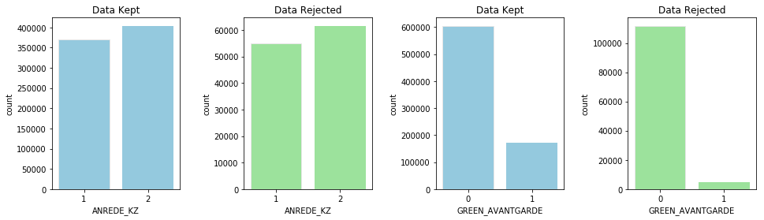

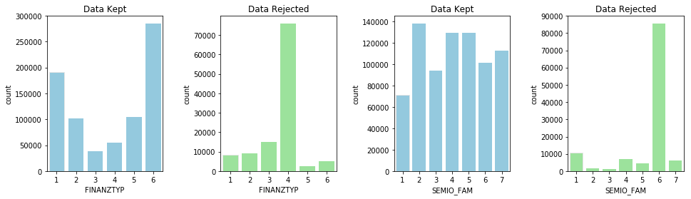

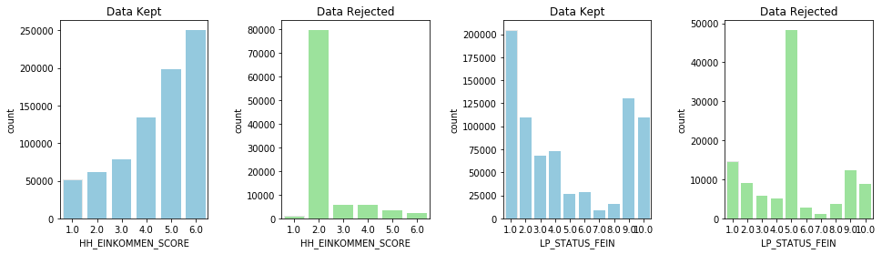

```python
# Columns chosen manually with zero or almost zero missing data
countplot('ANREDE_KZ','GREEN_AVANTGARDE','FINANZTYP','SEMIO_FAM','HH_EINKOMMEN_SCORE','LP_STATUS_FEIN')
```

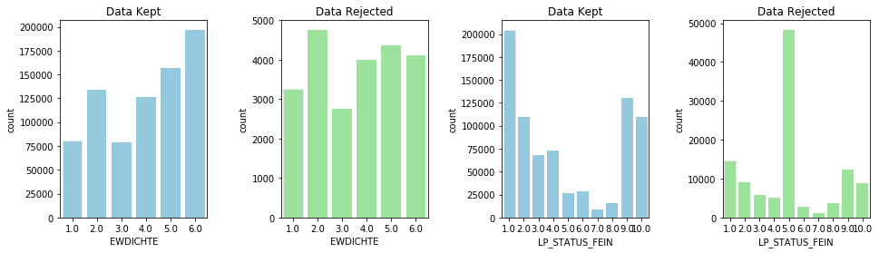

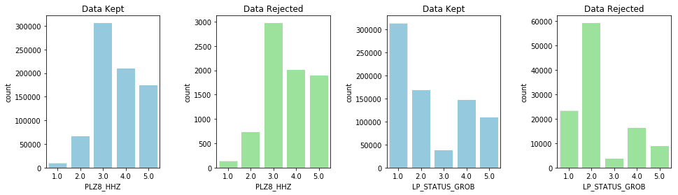

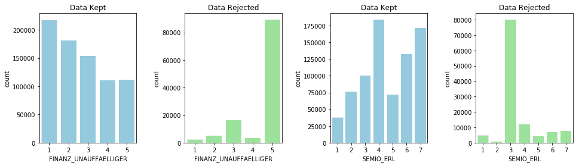

```python
# 6 columns chosen at random for comparison
s = list(col_comparison.sample(n=6))
countplot(s[0],s[1],s[2],s[3],s[4],s[5])
```

```python
# Checkpoint of azdias dataset taken
azdias_subset_1.to_csv('azdias_checkpoint_1.csv',sep=';',encoding='utf-8',index=False)
```

```python
# Load from checkpoint
azdias_2 = pd.read_csv('azdias_checkpoint_1.csv',sep=';')
feat_info = pd.read_csv('AZDIAS_Feature_Summary.csv',sep=';')
```

#### Discussion 1.1.3: Assess Missing Data in Each Row

First of all, we can see 623,209 rows are complete out of a total of 891,221 or 69.9%.

From the plots, we can see common missing number of observations in rows are 34, 45 and 47 missing observations with a combined total of 83,763 rows or 9.4%. With so many missing values I think the reliability and usefulness of these observations are limited, and the best decision is to drop them.

So zooming in on the plot we can see some natural breaks into the data at missing number of values at 9, 11, 17 and 20. The cumulative percentage of data retained at each of these cut off points are respectively; 9:86.6%, 11:87.7%, 17:89.3% and 20:89.5%. This means a difference of keeping an extra 25,376 rows between 9 missing observations on a row and 20 missing observations on a row.

Considering that the clustering algorithm K-means requires no missing information to work and that the dataset is made up of mainly ordinal and categorical data, where imputing values with means, modes or medians can impact the truth of the dataset much more than if the dataset was made up of numerical data. On balance, it seems more appropriate to minimize imputing missing data and maintain the integrity at maximum.

"It was a tough decision between discarding all rows with missing observations, therefore keeping 70% of the data but no imputation and the 9 missing rows, so keeping 87% of the data but imputing 148,492 values on the datset. To be honest in a real-world scenario I think I would have discarded all rows with any missing observations, on the basis that the German population over 18 is around 70 million. Therefore the difference between the two sample choices on the overall population is 0.2%. But I'm doing this course to learn so I want to do all the steps and practice everything."

With regards the data discarded with more than 9 missing observations. At first glance, the distributions within the variables in the most part seem different. Looking more closely at some of the variables manually chosen that have no missing observations only the gender "ANREDE_KZ" seems comparable, if you look at "HH_EINKOMMEN_SCORE" which shows an household net income the overwhelming majority of rows rejected show a 2 or very high income. This is also reflected in "LP_STATUS_FEIN" where the overwhelming majority of rows rejected are a 5 or minimalistic high-income earners. The missing observations in rows could relate to the extra privacy laws that protect high earners due the ease of being able to identify them from information. This would need more investigation to confirm.

### Step 1.2: Select and Re-Encode Features

Checking for missing data isn't the only way in which you can prepare a dataset for analysis. Since the unsupervised learning techniques to be used will only work on data that is encoded numerically, you need to make a few encoding changes or additional assumptions to be able to make progress. In addition, while almost all of the values in the dataset are encoded using numbers, not all of them represent numeric values. Check the third column of the feature summary (`feat_info`) for a summary of types of measurement.

- For numeric and interval data, these features can be kept without changes.
- Most of the variables in the dataset are ordinal in nature. While ordinal values may technically be non-linear in spacing, make the simplifying assumption that the ordinal variables can be treated as being interval in nature (that is, kept without any changes).
- Special handling may be necessary for the remaining two variable types: categorical, and 'mixed'.

In the first two parts of this sub-step, you will perform an investigation of the categorical and mixed-type features and make a decision on each of them, whether you will keep, drop, or re-encode each. Then, in the last part, you will create a new data frame with only the selected and engineered columns.

Data wrangling is often the trickiest part of the data analysis process, and there's a lot of it to be done here. But stick with it: once you're done with this step, you'll be ready to get to the machine learning parts of the project!

```python
# How many features are there of each data type?

print(feat_info['type'].value_counts())
```

```
ordinal        49
categorical    21
numeric         7
mixed           7
interval        1
Name: type, dtype: int64
```

```python
# Look at the categorical features
feat_info[feat_info['type'] == 'categorical']
```

|  | attribute | information_level | type | missing_or_unknown |
| --- | --- | --- | --- | --- |
| 0 | AGER_TYP | person | categorical | [-1,0] |
| 2 | ANREDE_KZ | person | categorical | [-1,0] |
| 3 | CJT_GESAMTTYP | person | categorical | [0] |
| 10 | FINANZTYP | person | categorical | [-1] |
| 12 | GFK_URLAUBERTYP | person | categorical | [] |
| 13 | GREEN_AVANTGARDE | person | categorical | [] |
| 17 | LP_FAMILIE_FEIN | person | categorical | [0] |
| 18 | LP_FAMILIE_GROB | person | categorical | [0] |
| 19 | LP_STATUS_FEIN | person | categorical | [0] |
| 20 | LP_STATUS_GROB | person | categorical | [0] |
| 21 | NATIONALITAET_KZ | person | categorical | [-1,0] |
| 38 | SHOPPER_TYP | person | categorical | [-1] |
| 39 | SOHO_KZ | person | categorical | [-1] |
| 40 | TITEL_KZ | person | categorical | [-1,0] |
| 41 | VERS_TYP | person | categorical | [-1] |
| 42 | ZABEOTYP | person | categorical | [-1,9] |
| 47 | KK_KUNDENTYP | household | categorical | [-1] |
| 52 | GEBAEUDETYP | building | categorical | [-1,0] |
| 55 | OST_WEST_KZ | building | categorical | [-1] |
| 57 | CAMEO_DEUG_2015 | microcell_rr4 | categorical | [-1,X] |
| 58 | CAMEO_DEU_2015 | microcell_rr4 | categorical | [XX] |

#### Step 1.2.1: Re-Encode Categorical Features

For categorical data, you would ordinarily need to encode the levels as dummy variables. Depending on the number of categories, perform one of the following:

- For binary (two-level) categoricals that take numeric values, you can keep them without needing to do anything.
- There is one binary variable that takes on non-numeric values. For this one, you need to re-encode the values as numbers or create a dummy variable.
- For multi-level categoricals (three or more values), you can choose to encode the values using multiple dummy variables (e.g. via [OneHotEncoder](http://scikit-learn.org/stable/modules/generated/sklearn.preprocessing.OneHotEncoder.html)), or (to keep things straightforward) just drop them from the analysis. As always, document your choices in the Discussion section.

```python
# Assess categorical variables: which are binary, which are multi-level, and
# which one needs to be re-encoded?

# Remove from feat_info dataframe colums that have already been deleted
feat_info = feat_info[feat_info.attribute != 'TITEL_KZ']
feat_info = feat_info[feat_info.attribute != 'AGER_TYP']
feat_info = feat_info[feat_info.attribute != 'KK_KUNDENTYP']
feat_info = feat_info[feat_info.attribute != 'KBA05_BAUMAX']
feat_info = feat_info[feat_info.attribute != 'GEBURTSJAHR']
feat_info = feat_info[feat_info.attribute != 'ALTER_HH']
```

```python
# Create a dataframe with only categorical variables
categorical_variables = azdias_2[feat_info[feat_info['type'] == 'categorical']['attribute']]
categorical_variables
```

|  | ANREDE_KZ | CJT_GESAMTTYP | FINANZTYP | GFK_URLAUBERTYP | GREEN_AVANTGARDE | LP_FAMILIE_FEIN | LP_FAMILIE_GROB | LP_STATUS_FEIN | LP_STATUS_GROB | NATIONALITAET_KZ | SHOPPER_TYP | SOHO_KZ | VERS_TYP | ZABEOTYP | GEBAEUDETYP | OST_WEST_KZ | CAMEO_DEUG_2015 | CAMEO_DEU_2015 |
| --- | --- | --- | --- | --- | --- | --- | --- | --- | --- | --- | --- | --- | --- | --- | --- | --- | --- | --- |
| 0 | 2 | 5.0 | 1 | 10.0 | 0 | 5.0 | 3.0 | 2.0 | 1.0 | 1.0 | 3.0 | 1.0 | 2.0 | 5 | 8.0 | W | 8.0 | 8A |
| 1 | 2 | 3.0 | 1 | 10.0 | 1 | 1.0 | 1.0 | 3.0 | 2.0 | 1.0 | 2.0 | 0.0 | 1.0 | 5 | 1.0 | W | 4.0 | 4C |
| 2 | 2 | 2.0 | 6 | 1.0 | 0 | NaN | NaN | 9.0 | 4.0 | 1.0 | 1.0 | 0.0 | 1.0 | 3 | 1.0 | W | 2.0 | 2A |
| 3 | 1 | 5.0 | 5 | 5.0 | 0 | 10.0 | 5.0 | 3.0 | 2.0 | 1.0 | 2.0 | 0.0 | 2.0 | 4 | 1.0 | W | 6.0 | 6B |
| 4 | 2 | 2.0 | 2 | 1.0 | 0 | 1.0 | 1.0 | 4.0 | 2.0 | 1.0 | 0.0 | 0.0 | 2.0 | 4 | 1.0 | W | 8.0 | 8C |
| 5 | 2 | 5.0 | 4 | 12.0 | 0 | 1.0 | 1.0 | 2.0 | 1.0 | 1.0 | 1.0 | 0.0 | 1.0 | 4 | 1.0 | W | 4.0 | 4A |
| 6 | 1 | 3.0 | 5 | 9.0 | 0 | 1.0 | 1.0 | 1.0 | 1.0 | 1.0 | 0.0 | 0.0 | 1.0 | 1 | 8.0 | W | 2.0 | 2D |
| 7 | 1 | 3.0 | 6 | 3.0 | 1 | 1.0 | 1.0 | 10.0 | 5.0 | 1.0 | 3.0 | 0.0 | 2.0 | 6 | 3.0 | W | 1.0 | 1A |
| 8 | 2 | 4.0 | 1 | 12.0 | 1 | 1.0 | 1.0 | 3.0 | 2.0 | 1.0 | 3.0 | 0.0 | 2.0 | 4 | 3.0 | W | 1.0 | 1E |
| 9 | 2 | 1.0 | 6 | 8.0 | 0 | 1.0 | 1.0 | 1.0 | 1.0 | 1.0 | 2.0 | 0.0 | 2.0 | 3 | 1.0 | W | 9.0 | 9D |
| 10 | 1 | 6.0 | 3 | 10.0 | 0 | 5.0 | 3.0 | 9.0 | 4.0 | 1.0 | 1.0 | 0.0 | 1.0 | 1 | 1.0 | W | 6.0 | 6B |
| 11 | 2 | 5.0 | 1 | 12.0 | 1 | 1.0 | 1.0 | 5.0 | 2.0 | 1.0 | 3.0 | 0.0 | 2.0 | 5 | 1.0 | W | 5.0 | 5C |
| 12 | 2 | 4.0 | 2 | 12.0 | 0 | 1.0 | 1.0 | 8.0 | 4.0 | 1.0 | 1.0 | 0.0 | 2.0 | 3 | 8.0 | W | 8.0 | 8B |
| 13 | 2 | 1.0 | 3 | 10.0 | 0 | NaN | NaN | 8.0 | 4.0 | 3.0 | 2.0 | 0.0 | 2.0 | 5 | 2.0 | W | 7.0 | 7A |
| 14 | 2 | 6.0 | 1 | 11.0 | 0 | 1.0 | 1.0 | 8.0 | 4.0 | 2.0 | 1.0 | 0.0 | 1.0 | 4 | 1.0 | W | 4.0 | 4C |
| 15 | 1 | 3.0 | 5 | 8.0 | 1 | 2.0 | 2.0 | 10.0 | 5.0 | 1.0 | 2.0 | 0.0 | 2.0 | 2 | 8.0 | W | 5.0 | 5D |
| 16 | 1 | 3.0 | 3 | 11.0 | 0 | 1.0 | 1.0 | 10.0 | 5.0 | 1.0 | 1.0 | 0.0 | 2.0 | 4 | 1.0 | W | 9.0 | 9E |
| 17 | 1 | 4.0 | 1 | 4.0 | 0 | 1.0 | 1.0 | 2.0 | 1.0 | 1.0 | 1.0 | 0.0 | 2.0 | 4 | 3.0 | W | 9.0 | 9D |
| 18 | 1 | 3.0 | 6 | 12.0 | 1 | 2.0 | 2.0 | 10.0 | 5.0 | 2.0 | 0.0 | 0.0 | 2.0 | 4 | 1.0 | W | 6.0 | 6B |
| 19 | 1 | 3.0 | 4 | 1.0 | 0 | NaN | NaN | 8.0 | 4.0 | 1.0 | 0.0 | 0.0 | 2.0 | 5 | 1.0 | W | 5.0 | 5C |
| 20 | 1 | 4.0 | 5 | 8.0 | 1 | 7.0 | 4.0 | 3.0 | 2.0 | 1.0 | 0.0 | 0.0 | 2.0 | 4 | 1.0 | W | 9.0 | 9B |
| 21 | 1 | 2.0 | 3 | 1.0 | 0 | 1.0 | 1.0 | 1.0 | 1.0 | 1.0 | 1.0 | 0.0 | 2.0 | 6 | 1.0 | W | 1.0 | 1A |
| 22 | 2 | 1.0 | 6 | 5.0 | 1 | 1.0 | 1.0 | 10.0 | 5.0 | 1.0 | 1.0 | 0.0 | 2.0 | 1 | 1.0 | W | 2.0 | 2A |
| 23 | 2 | 6.0 | 1 | 1.0 | 0 | 1.0 | 1.0 | 1.0 | 1.0 | 1.0 | 1.0 | 0.0 | 1.0 | 4 | 8.0 | W | 9.0 | 9D |
| 24 | 1 | 4.0 | 3 | 10.0 | 1 | 2.0 | 2.0 | 10.0 | 5.0 | 1.0 | 0.0 | 0.0 | 1.0 | 1 | 1.0 | W | 1.0 | 1B |
| 25 | 2 | 4.0 | 5 | 5.0 | 0 | 11.0 | 5.0 | 1.0 | 1.0 | 2.0 | 1.0 | 0.0 | 2.0 | 3 | 8.0 | W | 8.0 | 8B |
| 26 | 2 | 2.0 | 2 | 5.0 | 1 | 1.0 | 1.0 | 10.0 | 5.0 | NaN | NaN | 0.0 | NaN | 1 | 1.0 | W | 3.0 | 3D |
| 27 | 2 | 2.0 | 6 | 5.0 | 0 | 1.0 | 1.0 | 1.0 | 1.0 | 1.0 | 2.0 | 0.0 | 2.0 | 3 | 1.0 | W | 7.0 | 7A |
| 28 | 1 | 2.0 | 6 | 5.0 | 0 | 10.0 | 5.0 | 9.0 | 4.0 | 1.0 | 2.0 | 0.0 | 2.0 | 1 | 1.0 | W | 4.0 | 4C |
| 29 | 2 | 6.0 | 4 | 1.0 | 0 | 1.0 | 1.0 | 9.0 | 4.0 | 2.0 | 1.0 | 0.0 | 1.0 | 4 | 1.0 | W | 3.0 | 3D |
| ... | ... | ... | ... | ... | ... | ... | ... | ... | ... | ... | ... | ... | ... | ... | ... | ... | ... | ... |
| 774713 | 1 | 1.0 | 2 | 3.0 | 1 | 1.0 | 1.0 | 10.0 | 5.0 | 1.0 | 0.0 | 0.0 | 2.0 | 1 | 1.0 | W | 1.0 | 1D |
| 774714 | 2 | 1.0 | 2 | 6.0 | 0 | 1.0 | 1.0 | 4.0 | 2.0 | 1.0 | 3.0 | 0.0 | 2.0 | 3 | 1.0 | W | 6.0 | 6C |
| 774715 | 2 | 3.0 | 1 | 10.0 | 0 | 10.0 | 5.0 | 2.0 | 1.0 | 1.0 | 0.0 | 0.0 | 1.0 | 4 | 3.0 | W | 5.0 | 5B |
| 774716 | 1 | 3.0 | 5 | 4.0 | 0 | 2.0 | 2.0 | 3.0 | 2.0 | 1.0 | 2.0 | 0.0 | 1.0 | 4 | 1.0 | W | 6.0 | 6B |
| 774717 | 1 | 4.0 | 3 | 9.0 | 1 | 7.0 | 4.0 | 10.0 | 5.0 | 1.0 | 0.0 | 0.0 | 2.0 | 4 | 1.0 | W | 4.0 | 4C |
| 774718 | 2 | 6.0 | 2 | 5.0 | 0 | 10.0 | 5.0 | 3.0 | 2.0 | 1.0 | 3.0 | 0.0 | 2.0 | 3 | 1.0 | W | 8.0 | 8D |
| 774719 | 2 | 6.0 | 1 | 12.0 | 0 | 7.0 | 4.0 | 4.0 | 2.0 | 2.0 | 1.0 | 0.0 | 1.0 | 4 | 8.0 | W | 4.0 | 4B |
| 774720 | 2 | 1.0 | 5 | 5.0 | 1 | 1.0 | 1.0 | 10.0 | 5.0 | 1.0 | 2.0 | 0.0 | 2.0 | 4 | 3.0 | W | 3.0 | 3C |
| 774721 | 1 | 5.0 | 1 | 10.0 | 1 | 1.0 | 1.0 | 5.0 | 2.0 | 1.0 | 1.0 | 0.0 | 2.0 | 4 | 1.0 | W | 2.0 | 2C |
| 774722 | 1 | 3.0 | 1 | 11.0 | 0 | 1.0 | 1.0 | 1.0 | 1.0 | 2.0 | 2.0 | 0.0 | 1.0 | 4 | 8.0 | W | 8.0 | 8A |
| 774723 | 2 | 3.0 | 1 | 12.0 | 0 | 10.0 | 5.0 | 2.0 | 1.0 | 2.0 | 3.0 | 0.0 | 2.0 | 4 | 1.0 | W | 9.0 | 9A |
| 774724 | 1 | 3.0 | 6 | 7.0 | 0 | 1.0 | 1.0 | 3.0 | 2.0 | 1.0 | 2.0 | 0.0 | 2.0 | 4 | 3.0 | W | 7.0 | 7A |
| 774725 | 2 | 5.0 | 1 | 10.0 | 0 | 1.0 | 1.0 | 1.0 | 1.0 | 1.0 | 3.0 | 0.0 | 1.0 | 4 | 3.0 | W | 8.0 | 8B |
| 774726 | 1 | 5.0 | 6 | 11.0 | 0 | 11.0 | 5.0 | 9.0 | 4.0 | 1.0 | 0.0 | 0.0 | 2.0 | 1 | 3.0 | W | 3.0 | 3C |
| 774727 | 1 | 2.0 | 2 | 5.0 | 0 | 10.0 | 5.0 | 1.0 | 1.0 | 1.0 | 2.0 | 0.0 | 1.0 | 3 | 1.0 | W | 5.0 | 5E |
| 774728 | 2 | 4.0 | 4 | 12.0 | 0 | 1.0 | 1.0 | 9.0 | 4.0 | 1.0 | 0.0 | 0.0 | 2.0 | 5 | 1.0 | W | 3.0 | 3D |
| 774729 | 2 | 1.0 | 2 | 8.0 | 1 | 2.0 | 2.0 | 10.0 | 5.0 | 1.0 | 3.0 | 0.0 | 1.0 | 3 | 1.0 | W | 7.0 | 7A |
| 774730 | 1 | 2.0 | 6 | 10.0 | 0 | 2.0 | 2.0 | 9.0 | 4.0 | 1.0 | 3.0 | 0.0 | 2.0 | 1 | 1.0 | W | 2.0 | 2C |
| 774731 | 2 | 5.0 | 1 | 9.0 | 0 | 10.0 | 5.0 | 1.0 | 1.0 | 3.0 | 2.0 | 0.0 | 2.0 | 5 | 1.0 | W | 8.0 | 8A |
| 774732 | 1 | 5.0 | 6 | 4.0 | 0 | 1.0 | 1.0 | 1.0 | 1.0 | 1.0 | 2.0 | 0.0 | 2.0 | 3 | 8.0 | W | 8.0 | 8B |
| 774733 | 1 | 2.0 | 2 | 1.0 | 0 | 1.0 | 1.0 | 1.0 | 1.0 | 1.0 | 1.0 | 0.0 | 1.0 | 6 | 1.0 | W | 9.0 | 9D |
| 774734 | 1 | 1.0 | 5 | 4.0 | 0 | 1.0 | 1.0 | 1.0 | 1.0 | 1.0 | 2.0 | 0.0 | 1.0 | 3 | 3.0 | W | 9.0 | 9D |
| 774735 | 2 | 5.0 | 6 | 8.0 | 1 | 11.0 | 5.0 | 6.0 | 3.0 | 1.0 | 1.0 | 0.0 | 1.0 | 4 | 3.0 | W | 5.0 | 5E |
| 774736 | 2 | 4.0 | 1 | 10.0 | 0 | 1.0 | 1.0 | 1.0 | 1.0 | 1.0 | 3.0 | 0.0 | 2.0 | 5 | 1.0 | W | 3.0 | 3A |
| 774737 | 2 | 6.0 | 1 | 12.0 | 0 | 1.0 | 1.0 | 2.0 | 1.0 | 2.0 | 1.0 | 0.0 | 1.0 | 4 | 1.0 | W | 5.0 | 5A |
| 774738 | 2 | 5.0 | 1 | 12.0 | 0 | 1.0 | 1.0 | 2.0 | 1.0 | 1.0 | 3.0 | 0.0 | 1.0 | 4 | 8.0 | W | 7.0 | 7A |
| 774739 | 1 | 4.0 | 6 | 1.0 | 0 | 1.0 | 1.0 | 1.0 | 1.0 | NaN | NaN | 0.0 | NaN | 6 | 8.0 | W | 9.0 | 9D |
| 774740 | 2 | 4.0 | 1 | 10.0 | 0 | NaN | NaN | 4.0 | 2.0 | 1.0 | 2.0 | 0.0 | 1.0 | 4 | 8.0 | W | 4.0 | 4C |
| 774741 | 1 | 3.0 | 1 | 9.0 | 0 | 9.0 | 5.0 | 2.0 | 1.0 | 1.0 | 0.0 | 0.0 | 2.0 | 5 | 8.0 | W | 9.0 | 9D |
| 774742 | 1 | 1.0 | 6 | 12.0 | 0 | 1.0 | 1.0 | 1.0 | 1.0 | 1.0 | 2.0 | 0.0 | 1.0 | 3 | 8.0 | W | 6.0 | 6B |

774743 rows × 18 columns

```python
# List for reference of categorical variables
categorical_variables.info()
```

```
<class 'pandas.core.frame.DataFrame'>
RangeIndex: 774743 entries, 0 to 774742
Data columns (total 18 columns):
ANREDE_KZ           774743 non-null int64
CJT_GESAMTTYP       774743 non-null float64
FINANZTYP           774743 non-null int64
GFK_URLAUBERTYP     774743 non-null float64
GREEN_AVANTGARDE    774743 non-null int64
LP_FAMILIE_FEIN     750265 non-null float64
LP_FAMILIE_GROB     750265 non-null float64
LP_STATUS_FEIN      774743 non-null float64
LP_STATUS_GROB      774743 non-null float64
NATIONALITAET_KZ    743919 non-null float64
SHOPPER_TYP         741323 non-null float64
SOHO_KZ             774743 non-null float64
VERS_TYP            741323 non-null float64
ZABEOTYP            774743 non-null int64
GEBAEUDETYP         774743 non-null float64
OST_WEST_KZ         774743 non-null object
CAMEO_DEUG_2015     771287 non-null float64
CAMEO_DEU_2015      771287 non-null object
dtypes: float64(12), int64(4), object(2)
memory usage: 106.4+ MB
```

```python
# Separate the categorical variables into binary or multi-variable
binary = []
multivar = []
for x in categorical_variables:
    if len(categorical_variables[x].value_counts()) == 2:
        binary.append(x)
    else:
        multivar.append(x)
```

```python
# Binary list
binary
```

```
['ANREDE_KZ', 'GREEN_AVANTGARDE', 'SOHO_KZ', 'VERS_TYP', 'OST_WEST_KZ']
```

```python
# Multi-variable list
multivar
```

```
['CJT_GESAMTTYP',
 'FINANZTYP',
 'GFK_URLAUBERTYP',
 'LP_FAMILIE_FEIN',
 'LP_FAMILIE_GROB',
 'LP_STATUS_FEIN',
 'LP_STATUS_GROB',
 'NATIONALITAET_KZ',
 'SHOPPER_TYP',
 'ZABEOTYP',
 'GEBAEUDETYP',
 'CAMEO_DEUG_2015',
 'CAMEO_DEU_2015']
```

```python
# Find binary categorical variable non-numeric
azdias_2['ANREDE_KZ'].unique()
```

```
array([2, 1])
```

```python
# Find binary categorical variable non-numeric
azdias_2['GREEN_AVANTGARDE'].unique()
```

```
array([0, 1])
```

```python
# Find binary categorical variable non-numeric
azdias_2['SOHO_KZ'].unique()
```

```
array([ 1.,  0.])
```

```python
# Find binary categorical variable non-numeric
azdias_2['VERS_TYP'].unique()
```

```
array([  2.,   1.,  nan])
```

```python
# Find binary categorical variable non-numeric - located it
azdias_2['OST_WEST_KZ'].unique()
```

```
array(['W', 'O'], dtype=object)
```

```python
# Change 'OST_WEST_KZ into numerical values
azdias_2['OST_WEST_KZ'] = azdias_2['OST_WEST_KZ'].map({'W': 1, 'O': 0})
```

```python
# Analysis of column "GEBAEUDETYP"
azdias_2['GEBAEUDETYP'].value_counts().sort_index()
```

```
1.0    444164
2.0      4294
3.0    174605
4.0       809
5.0         1
6.0       548
8.0    150322
Name: GEBAEUDETYP, dtype: int64
```

```python
# Simplify 'GEBAEUDETYP' Type of building use into 3 categories; 1 = residential, 2 = mixed usage, 3 = commercial
azdias_2['GEBAEUDETYP'] = azdias_2['GEBAEUDETYP'].map({1:1,2:1,3:2,4:2,5:3,6:2,7:3,8:2})
```

```python
# Check mapping has worked - After reviewing these numbers decided to drop as provide no added value information
# for customer segmentation.
azdias_2['GEBAEUDETYP'].value_counts().sort_index()
```

```
1    448458
2    326284
3         1
Name: GEBAEUDETYP, dtype: int64
```

```python
# Deep analysis of multi-variable category CAMEO_DEU_2015
azdias_2['CAMEO_DEU_2015'].value_counts().sort_index()
```

```
1A    10571
1B     3970
1C     4188
1D    11699
1E     4946
2A    12795
2B    14906
2C    18731
2D    34105
3A     8698
3B     6668
3C    33893
3D    33401
4A    31990
4B     8745
4C    46283
4D     8383
4E     5186
5A    11074
5B    10087
5C     9571
5D    14594
5E     3517
5F     4183
6A     6647
6B    55429
6C    14502
6D     5956
6E    15838
6F     5263
7A    33648
7B    23954
7C     8920
7D     5234
7E     4509
8A    51807
8B    32828
8C    30591
8D    17337
9A    20258
9B    27359
9C    24705
9D    28215
9E     6103
Name: CAMEO_DEU_2015, dtype: int64
```

```python
# Drop multi-variable columns not required
cols_to_drop = ['LP_FAMILIE_GROB','LP_STATUS_GROB','GEBAEUDETYP','CAMEO_DEU_2015']
azdias_2 = azdias_2.drop(cols_to_drop,axis=1)
```

```python
# Re-encode categorical variable(s) to be kept in the analysis.

multi = []

for x in multivar:
    if x not in cols_to_drop:
        multi.append(x)

multi
```

```
['CJT_GESAMTTYP',
 'FINANZTYP',
 'GFK_URLAUBERTYP',
 'LP_FAMILIE_FEIN',
 'LP_STATUS_FEIN',
 'NATIONALITAET_KZ',
 'SHOPPER_TYP',
 'ZABEOTYP',
 'CAMEO_DEUG_2015']
```

```python
# One Hot Encode remaining multi-variable categorical variables
azdias_2 = pd.get_dummies(azdias_2, columns = multi, prefix=multi)
```

```python
azdias_2.head()
```

|  | ALTERSKATEGORIE_GROB | ANREDE_KZ | FINANZ_MINIMALIST | FINANZ_SPARER | FINANZ_VORSORGER | FINANZ_ANLEGER | FINANZ_UNAUFFAELLIGER | FINANZ_HAUSBAUER | GREEN_AVANTGARDE | HEALTH_TYP | ... | ZABEOTYP_6 | CAMEO_DEUG_2015_1.0 | CAMEO_DEUG_2015_2.0 | CAMEO_DEUG_2015_3.0 | CAMEO_DEUG_2015_4.0 | CAMEO_DEUG_2015_5.0 | CAMEO_DEUG_2015_6.0 | CAMEO_DEUG_2015_7.0 | CAMEO_DEUG_2015_8.0 | CAMEO_DEUG_2015_9.0 |
| --- | --- | --- | --- | --- | --- | --- | --- | --- | --- | --- | --- | --- | --- | --- | --- | --- | --- | --- | --- | --- | --- |
| 0 | 1.0 | 2 | 1 | 5 | 2 | 5 | 4 | 5 | 0 | 3.0 | ... | 0 | 0 | 0 | 0 | 0 | 0 | 0 | 0 | 1 | 0 |
| 1 | 3.0 | 2 | 1 | 4 | 1 | 2 | 3 | 5 | 1 | 3.0 | ... | 0 | 0 | 0 | 0 | 1 | 0 | 0 | 0 | 0 | 0 |
| 2 | 4.0 | 2 | 4 | 2 | 5 | 2 | 1 | 2 | 0 | 2.0 | ... | 0 | 0 | 1 | 0 | 0 | 0 | 0 | 0 | 0 | 0 |
| 3 | 3.0 | 1 | 4 | 3 | 4 | 1 | 3 | 2 | 0 | 3.0 | ... | 0 | 0 | 0 | 0 | 0 | 0 | 1 | 0 | 0 | 0 |
| 4 | 1.0 | 2 | 3 | 1 | 5 | 2 | 2 | 5 | 0 | 3.0 | ... | 0 | 0 | 0 | 0 | 0 | 0 | 0 | 0 | 1 | 0 |

5 rows × 133 columns

```python
azdias_2.shape
```

```
(774743, 133)
```

#### Discussion 1.2.1: Re-Encode Categorical Features

For the categorical features, I first isolated which columns classed as categorical and separated them between binary variables i.e. ones with 2 values and multiple variables.

The 5 binary categorical features, all give information that I think could be relevant for forming customer segments so the decision was to keep them all including the non-numerical one which related to whether the building in which the individual lives is in what was the old East or West Germany prior to 1991. After 27 years this feature is probably waning in usefulness compared to 10 or 20 years ago when analysing customer segments.

For the multi categorical variables, I analysed each individually: The following categories ("CJT_GESAMTTYP", "FINANZTYP", "NATIONALITAET_KZ", "SHOPPER_TYP","ZABEOTYP") all related to person-level features without being too detailed so the decision was to keep them and one hot encode them.

For "LP_FAMILIE_FEIN","LP_FAMILIE_GROB","LP_STATUS_FEIN", and "LP_STATUS_GROB', the decision was to drop the Grobs which were summaries of the Feins. I thought the level of segregation was better for identifying customer segments in the more detailed Fein scales but it was unnecessary to keep both.

The category "GEBAEUDETYP" once summarized provided no additional value for customer segmentation as it related to building-level feature which could be inferred from 3.1 "ANZ_HAUSHALTE_AKTIV" so it was decided to drop it.

Between "CAMEO_DEUG_2015", and "CAMEO_DEU_2015", which both relate to wealth/life stage typology with the first using a rough scale and the second a very detailed marketing scale. I decided to keep only the rough scale. When you look through all the categories in the feature info list, the majority are at a higher level in detail to "CAMEO_DEU_2015". "CAMEO_DEU_2015" seems to be a level of detail too high for this particular customer segment analysis, I think it would be appropriate to use this in a second analysis after primary customer segments have been identified for fine-tuning marketing efforts. Also there are many categories and one hot encoding these would add many features to our analysis and I am not convinced it would add value to this particular segment analysis.

Lastly, "GFK_URLAUBERTYP" is a detailed analysis of vacation habits with 12 categories. It was a close choice on whether to keep or drop for the same reasons discussed in the paragraph above on the level of detail for this particular analysis. On the balance of number of categories and that it was a person-level feature I have kept it and one hot encoded it.

#### Step 1.2.2: Engineer Mixed-Type Features

There are a handful of features that are marked as "mixed" in the feature summary that require special treatment in order to be included in the analysis. There are two in particular that deserve attention; the handling of the rest are up to your own choices:

- "PRAEGENDE_JUGENDJAHRE" combines information on three dimensions: generation by decade, movement (mainstream vs. avantgarde), and nation (east vs. west). While there aren't enough levels to disentangle east from west, you should create two new variables to capture the other two dimensions: an interval-type variable for decade, and a binary variable for movement.
- "CAMEO_INTL_2015" combines information on two axes: wealth and life stage. Break up the two-digit codes by their 'tens'-place and 'ones'-place digits into two new ordinal variables (which, for the purposes of this project, is equivalent to just treating them as their raw numeric values).
- If you decide to keep or engineer new features around the other mixed-type features, make sure you note your steps in the Discussion section.

Be sure to check `Data_Dictionary.md` for the details needed to finish these tasks.

```python
# Identify features classified as mixed
feat_info[feat_info['type'] == 'mixed']
```

|  | attribute | information_level | type | missing_or_unknown |
| --- | --- | --- | --- | --- |
| 15 | LP_LEBENSPHASE_FEIN | person | mixed | [0] |
| 16 | LP_LEBENSPHASE_GROB | person | mixed | [0] |
| 22 | PRAEGENDE_JUGENDJAHRE | person | mixed | [-1,0] |
| 56 | WOHNLAGE | building | mixed | [-1] |
| 59 | CAMEO_INTL_2015 | microcell_rr4 | mixed | [-1,XX] |
| 79 | PLZ8_BAUMAX | macrocell_plz8 | mixed | [-1,0] |

```python
# Investigate "PRAEGENDE_JUGENDJAHRE" and engineer two new variables.
azdias_2['PRAEGENDE_JUGENDJAHRE'].value_counts()
```

```
14.0    177574
8.0     137903
10.0     83394
5.0      83112
3.0      52758
15.0     40803
11.0     34385
9.0      32939
6.0      25311
12.0     23925
4.0      20185
1.0      20106
2.0       7387
13.0      5520
7.0       3939
Name: PRAEGENDE_JUGENDJAHRE, dtype: int64
```

```python
# Engineer a column "AVANTGARDE"
avantgarde = []

for x in azdias_2['PRAEGENDE_JUGENDJAHRE']:
    if x in [1,3,5,8,10,12,14]:
        avantgarde.append(0) # Value 0 denotes 'Mainstream'
    elif x in [2,4,6,7,9,11,13,15]:
        avantgarde.append(1) # Value 1 denotes 'Avantgarde'
    else:
        avantgarde.append(np.nan)
```

```python
# Add new column "AVANTGARDE" to azdias dataframe
a = pd.Series(avantgarde)
azdias_2['AVANTGARDE'] = a.values
azdias_2.head()
```

|  | ALTERSKATEGORIE_GROB | ANREDE_KZ | FINANZ_MINIMALIST | FINANZ_SPARER | FINANZ_VORSORGER | FINANZ_ANLEGER | FINANZ_UNAUFFAELLIGER | FINANZ_HAUSBAUER | GREEN_AVANTGARDE | HEALTH_TYP | ... | CAMEO_DEUG_2015_1.0 | CAMEO_DEUG_2015_2.0 | CAMEO_DEUG_2015_3.0 | CAMEO_DEUG_2015_4.0 | CAMEO_DEUG_2015_5.0 | CAMEO_DEUG_2015_6.0 | CAMEO_DEUG_2015_7.0 | CAMEO_DEUG_2015_8.0 | CAMEO_DEUG_2015_9.0 | AVANTGARDE |
| --- | --- | --- | --- | --- | --- | --- | --- | --- | --- | --- | --- | --- | --- | --- | --- | --- | --- | --- | --- | --- | --- |
| 0 | 1.0 | 2 | 1 | 5 | 2 | 5 | 4 | 5 | 0 | 3.0 | ... | 0 | 0 | 0 | 0 | 0 | 0 | 0 | 1 | 0 | 0.0 |
| 1 | 3.0 | 2 | 1 | 4 | 1 | 2 | 3 | 5 | 1 | 3.0 | ... | 0 | 0 | 0 | 1 | 0 | 0 | 0 | 0 | 0 | 1.0 |
| 2 | 4.0 | 2 | 4 | 2 | 5 | 2 | 1 | 2 | 0 | 2.0 | ... | 0 | 1 | 0 | 0 | 0 | 0 | 0 | 0 | 0 | 0.0 |
| 3 | 3.0 | 1 | 4 | 3 | 4 | 1 | 3 | 2 | 0 | 3.0 | ... | 0 | 0 | 0 | 0 | 0 | 1 | 0 | 0 | 0 | 0.0 |
| 4 | 1.0 | 2 | 3 | 1 | 5 | 2 | 2 | 5 | 0 | 3.0 | ... | 0 | 0 | 0 | 0 | 0 | 0 | 0 | 1 | 0 | 0.0 |

5 rows × 134 columns

```python
# Check engineering successful
azdias_2['AVANTGARDE'].value_counts()
```

```
0.0    578772
1.0    170469
Name: AVANTGARDE, dtype: int64
```

```python
# Engineer new column "DEKADE" based on decade of birth
azdias_2['DEKADE'] = azdias_2['PRAEGENDE_JUGENDJAHRE'].map({1:1,2:1,3:2,4:2,5:3,6:3,7:3,8:4,9:4,10:5,11:5,12:5,13:5,14:6,15:6})
```

```python
# Check engineering
azdias_2['DEKADE'].value_counts().sort_index()
```

```
1.0     27493
2.0     72943
3.0    112362
4.0    170842
5.0    147224
6.0    218377
Name: DEKADE, dtype: int64
```

```python
# Drop original column from dataframe
azdias_2 = azdias_2.drop('PRAEGENDE_JUGENDJAHRE',axis=1)
```

```python
# Check dataframe
azdias_2[:10]
```

|  | ALTERSKATEGORIE_GROB | ANREDE_KZ | FINANZ_MINIMALIST | FINANZ_SPARER | FINANZ_VORSORGER | FINANZ_ANLEGER | FINANZ_UNAUFFAELLIGER | FINANZ_HAUSBAUER | GREEN_AVANTGARDE | HEALTH_TYP | ... | CAMEO_DEUG_2015_2.0 | CAMEO_DEUG_2015_3.0 | CAMEO_DEUG_2015_4.0 | CAMEO_DEUG_2015_5.0 | CAMEO_DEUG_2015_6.0 | CAMEO_DEUG_2015_7.0 | CAMEO_DEUG_2015_8.0 | CAMEO_DEUG_2015_9.0 | AVANTGARDE | DEKADE |
| --- | --- | --- | --- | --- | --- | --- | --- | --- | --- | --- | --- | --- | --- | --- | --- | --- | --- | --- | --- | --- | --- |
| 0 | 1.0 | 2 | 1 | 5 | 2 | 5 | 4 | 5 | 0 | 3.0 | ... | 0 | 0 | 0 | 0 | 0 | 0 | 1 | 0 | 0.0 | 6.0 |
| 1 | 3.0 | 2 | 1 | 4 | 1 | 2 | 3 | 5 | 1 | 3.0 | ... | 0 | 0 | 1 | 0 | 0 | 0 | 0 | 0 | 1.0 | 6.0 |
| 2 | 4.0 | 2 | 4 | 2 | 5 | 2 | 1 | 2 | 0 | 2.0 | ... | 1 | 0 | 0 | 0 | 0 | 0 | 0 | 0 | 0.0 | 4.0 |
| 3 | 3.0 | 1 | 4 | 3 | 4 | 1 | 3 | 2 | 0 | 3.0 | ... | 0 | 0 | 0 | 0 | 1 | 0 | 0 | 0 | 0.0 | 4.0 |
| 4 | 1.0 | 2 | 3 | 1 | 5 | 2 | 2 | 5 | 0 | 3.0 | ... | 0 | 0 | 0 | 0 | 0 | 0 | 1 | 0 | 0.0 | 2.0 |
| 5 | 2.0 | 2 | 1 | 5 | 1 | 5 | 4 | 3 | 0 | 2.0 | ... | 0 | 0 | 1 | 0 | 0 | 0 | 0 | 0 | 0.0 | 5.0 |
| 6 | 1.0 | 1 | 3 | 3 | 4 | 1 | 3 | 2 | 0 | 1.0 | ... | 1 | 0 | 0 | 0 | 0 | 0 | 0 | 0 | 0.0 | 4.0 |
| 7 | 3.0 | 1 | 4 | 4 | 2 | 4 | 2 | 2 | 1 | 3.0 | ... | 0 | 0 | 0 | 0 | 0 | 0 | 0 | 0 | 1.0 | 5.0 |
| 8 | 3.0 | 2 | 2 | 4 | 2 | 3 | 5 | 4 | 1 | 2.0 | ... | 0 | 0 | 0 | 0 | 0 | 0 | 0 | 0 | 1.0 | 6.0 |
| 9 | 3.0 | 2 | 2 | 2 | 5 | 3 | 1 | 5 | 0 | 2.0 | ... | 0 | 0 | 0 | 0 | 0 | 0 | 0 | 1 | 0.0 | 2.0 |

10 rows × 134 columns

```python
# Investigate "CAMEO_INTL_2015" and engineer two new variables.

azdias_2['CAMEO_INTL_2015'].value_counts()
```

```
51.0    132086
41.0     90430
24.0     88559
14.0     60994
43.0     55429
54.0     44745
25.0     38587
22.0     31990
45.0     25610
13.0     25477
23.0     24111
55.0     23440
52.0     20258
34.0     18111
31.0     17721
15.0     16645
44.0     14502
12.0     12795
35.0     10139
32.0     10087
33.0      9571
Name: CAMEO_INTL_2015, dtype: int64
```

```python
# Engineer a feature based on household wealth
cameo_wealth = []

for x in azdias_2['CAMEO_INTL_2015']:
    if 10 < x < 16:
        cameo_wealth.append(5)
    elif 20 < x < 26:
        cameo_wealth.append(4)
    elif 30 < x < 36:
        cameo_wealth.append(3)
    elif 40 < x < 46:
        cameo_wealth.append(2)
    elif 50 < x < 56:
        cameo_wealth.append(1)
    else:
        cameo_wealth.append(np.nan)
```

```python
cw = pd.Series(cameo_wealth)
azdias_2['CAMEO_WEALTH'] = cw.values
```

```python
azdias_2['CAMEO_WEALTH'].value_counts().sort_index()
```

```
1.0    220529
2.0    185971
3.0     65629
4.0    183247
5.0    115911
Name: CAMEO_WEALTH, dtype: int64
```

```python
# Engineer a feature based on household lifestage
cameo_lifestage = []

for x in azdias_2['CAMEO_INTL_2015']:
    if x % 10 == 1:
        cameo_lifestage.append(1)
    elif x % 10 == 2:
        cameo_lifestage.append(2)
    elif x % 10 == 3:
        cameo_lifestage.append(3)
    elif x % 10 == 4:
        cameo_lifestage.append(4)
    elif x % 10 == 5:
        cameo_lifestage.append(5)
    else:
        cameo_lifestage.append(np.nan)
```

```python
cl = pd.Series(cameo_lifestage)
azdias_2['CAMEO_LIFESTAGE'] = cl.values
```

```python
azdias_2['CAMEO_LIFESTAGE'].value_counts().sort_index()
```

```
1.0    240237
2.0     75130
3.0    114588
4.0    226911
5.0    114421
Name: CAMEO_LIFESTAGE, dtype: int64
```

```python
# Remove original column
azdias_2 = azdias_2.drop(['CAMEO_INTL_2015'],axis=1)
```

```python
# Verify re-engineering of "CAMEO_INTL_2015
azdias_2.head()
```

|  | ALTERSKATEGORIE_GROB | ANREDE_KZ | FINANZ_MINIMALIST | FINANZ_SPARER | FINANZ_VORSORGER | FINANZ_ANLEGER | FINANZ_UNAUFFAELLIGER | FINANZ_HAUSBAUER | GREEN_AVANTGARDE | HEALTH_TYP | ... | CAMEO_DEUG_2015_4.0 | CAMEO_DEUG_2015_5.0 | CAMEO_DEUG_2015_6.0 | CAMEO_DEUG_2015_7.0 | CAMEO_DEUG_2015_8.0 | CAMEO_DEUG_2015_9.0 | AVANTGARDE | DEKADE | CAMEO_WEALTH | CAMEO_LIFESTAGE |
| --- | --- | --- | --- | --- | --- | --- | --- | --- | --- | --- | --- | --- | --- | --- | --- | --- | --- | --- | --- | --- | --- |
| 0 | 1.0 | 2 | 1 | 5 | 2 | 5 | 4 | 5 | 0 | 3.0 | ... | 0 | 0 | 0 | 0 | 1 | 0 | 0.0 | 6.0 | 1.0 | 1.0 |
| 1 | 3.0 | 2 | 1 | 4 | 1 | 2 | 3 | 5 | 1 | 3.0 | ... | 1 | 0 | 0 | 0 | 0 | 0 | 1.0 | 6.0 | 4.0 | 4.0 |
| 2 | 4.0 | 2 | 4 | 2 | 5 | 2 | 1 | 2 | 0 | 2.0 | ... | 0 | 0 | 0 | 0 | 0 | 0 | 0.0 | 4.0 | 5.0 | 2.0 |
| 3 | 3.0 | 1 | 4 | 3 | 4 | 1 | 3 | 2 | 0 | 3.0 | ... | 0 | 0 | 1 | 0 | 0 | 0 | 0.0 | 4.0 | 2.0 | 3.0 |
| 4 | 1.0 | 2 | 3 | 1 | 5 | 2 | 2 | 5 | 0 | 3.0 | ... | 0 | 0 | 0 | 0 | 1 | 0 | 0.0 | 2.0 | 1.0 | 4.0 |

5 rows × 135 columns

```python
azdias_2['WOHNLAGE'].value_counts().sort_index()
```

```
0.0      2941
1.0     42859
2.0     98105
3.0    244502
4.0    133116
5.0     72346
7.0    165983
8.0     14891
Name: WOHNLAGE, dtype: int64
```

```python
# Engineer a feature based on rural or not
azdias_2['RURAL'] = azdias_2['WOHNLAGE'].map({0:0,1:0,2:0,3:0,4:0,5:0,7:1,8:1})
```

```python
# Engineer a feature based on quality of neighborhood
azdias_2['GEGEND'] = azdias_2['WOHNLAGE'].map({0:0,1:1,2:2,3:3,4:4,5:5,7:0,8:0})
```

```python
# Drop mixed features not required
azdias_2 = azdias_2.drop(['LP_LEBENSPHASE_FEIN','LP_LEBENSPHASE_GROB','WOHNLAGE','PLZ8_BAUMAX'],axis=1)
```

```python
azdias_2.shape
```

```
(774743, 133)
```

```python
# Check dataframe features
azdias_2.head()
```

|  | ALTERSKATEGORIE_GROB | ANREDE_KZ | FINANZ_MINIMALIST | FINANZ_SPARER | FINANZ_VORSORGER | FINANZ_ANLEGER | FINANZ_UNAUFFAELLIGER | FINANZ_HAUSBAUER | GREEN_AVANTGARDE | HEALTH_TYP | ... | CAMEO_DEUG_2015_6.0 | CAMEO_DEUG_2015_7.0 | CAMEO_DEUG_2015_8.0 | CAMEO_DEUG_2015_9.0 | AVANTGARDE | DEKADE | CAMEO_WEALTH | CAMEO_LIFESTAGE | RURAL | GEGEND |
| --- | --- | --- | --- | --- | --- | --- | --- | --- | --- | --- | --- | --- | --- | --- | --- | --- | --- | --- | --- | --- | --- |
| 0 | 1.0 | 2 | 1 | 5 | 2 | 5 | 4 | 5 | 0 | 3.0 | ... | 0 | 0 | 1 | 0 | 0.0 | 6.0 | 1.0 | 1.0 | 0 | 4 |
| 1 | 3.0 | 2 | 1 | 4 | 1 | 2 | 3 | 5 | 1 | 3.0 | ... | 0 | 0 | 0 | 0 | 1.0 | 6.0 | 4.0 | 4.0 | 0 | 2 |
| 2 | 4.0 | 2 | 4 | 2 | 5 | 2 | 1 | 2 | 0 | 2.0 | ... | 0 | 0 | 0 | 0 | 0.0 | 4.0 | 5.0 | 2.0 | 1 | 0 |
| 3 | 3.0 | 1 | 4 | 3 | 4 | 1 | 3 | 2 | 0 | 3.0 | ... | 1 | 0 | 0 | 0 | 0.0 | 4.0 | 2.0 | 3.0 | 0 | 3 |
| 4 | 1.0 | 2 | 3 | 1 | 5 | 2 | 2 | 5 | 0 | 3.0 | ... | 0 | 0 | 1 | 0 | 0.0 | 2.0 | 1.0 | 4.0 | 1 | 0 |

5 rows × 133 columns

#### Discussion 1.2.2: Engineer Mixed-Type Features

The 2 variables "PRAEGENDE_JUGENDJAHRE" and "CAMEO_INTL_2015" were re-engineered into 4 new features as required at the start of this section. ("AVANTGARDE", "DEKADE", "CAMEO_WEALTH" and "CAMEO_LIFESTAGE")

The "CAMEO_INTL_2015" was interesting as the wealth feature engineered is very similar to the "CAMEO_DEUG_2015" categorical feature one hot encoded in the previous section. I thought about whether both features were necessary. After consideration I concluded that even though the "CAMEO_INTL_2015" was created from the German "CAMEO", the slightly different classifications could allow for a more refined cluster analysis. So I decided to keep both instead of dropping one.

For other mixed-type features ('LP_LEBENSPHASE_FEIN','LP_LEBENSPHASE_GROB') were dropped on the basis that the information in these features were already included in other features in the dataset, 1.2 "ALTERSKATEGORIE_GROB", 1.13 "LP_FAMILIE_FEIN" and 1.15 "LP_STATUS_FEIN" and it wasn't necessary to re-engineer and keep them in the dataset.

However, for the last feature, 'WOHNLAGE', I thought the quality of the neighborhood could impact customer segments and this information wasn't available in other features, I re-engineered "WOHNLAGE" into 2 features, the first a binary categorical feature, whether the neighbourhood was rural or not, and the second into a rating class for the neighborhood. For rural neighborhoods I classed them as no score calculated.

#### Step 1.2.3: Complete Feature Selection

In order to finish this step up, you need to make sure that your data frame now only has the columns that you want to keep. To summarize, the dataframe should consist of the following:

- All numeric, interval, and ordinal type columns from the original dataset.
- Binary categorical features (all numerically-encoded).
- Engineered features from other multi-level categorical features and mixed features.

Make sure that for any new columns that you have engineered, that you've excluded the original columns from the final dataset. Otherwise, their values will interfere with the analysis later on the project. For example, you should not keep "PRAEGENDE_JUGENDJAHRE", since its values won't be useful for the algorithm: only the values derived from it in the engineered features you created should be retained. As a reminder, your data should only be from **the subset with few or no missing values**.

```python
# Review of features
azdias_2[:1].transpose()
```

|  | 0 |
| --- | --- |
| ALTERSKATEGORIE_GROB | 1.0 |
| ANREDE_KZ | 2.0 |
| FINANZ_MINIMALIST | 1.0 |
| FINANZ_SPARER | 5.0 |
| FINANZ_VORSORGER | 2.0 |
| FINANZ_ANLEGER | 5.0 |
| FINANZ_UNAUFFAELLIGER | 4.0 |
| FINANZ_HAUSBAUER | 5.0 |
| GREEN_AVANTGARDE | 0.0 |
| HEALTH_TYP | 3.0 |
| RETOURTYP_BK_S | 1.0 |
| SEMIO_SOZ | 5.0 |
| SEMIO_FAM | 4.0 |
| SEMIO_REL | 4.0 |
| SEMIO_MAT | 3.0 |
| SEMIO_VERT | 1.0 |
| SEMIO_LUST | 2.0 |
| SEMIO_ERL | 2.0 |
| SEMIO_KULT | 3.0 |
| SEMIO_RAT | 6.0 |
| SEMIO_KRIT | 4.0 |
| SEMIO_DOM | 7.0 |
| SEMIO_KAEM | 4.0 |
| SEMIO_PFLICHT | 7.0 |
| SEMIO_TRADV | 6.0 |
| SOHO_KZ | 1.0 |
| VERS_TYP | 2.0 |
| ANZ_PERSONEN | 2.0 |
| ANZ_TITEL | 0.0 |
| HH_EINKOMMEN_SCORE | 6.0 |
| ... | ... |
| LP_STATUS_FEIN_9.0 | 0.0 |
| LP_STATUS_FEIN_10.0 | 0.0 |
| NATIONALITAET_KZ_1.0 | 1.0 |
| NATIONALITAET_KZ_2.0 | 0.0 |
| NATIONALITAET_KZ_3.0 | 0.0 |
| SHOPPER_TYP_0.0 | 0.0 |
| SHOPPER_TYP_1.0 | 0.0 |
| SHOPPER_TYP_2.0 | 0.0 |
| SHOPPER_TYP_3.0 | 1.0 |
| ZABEOTYP_1 | 0.0 |
| ZABEOTYP_2 | 0.0 |
| ZABEOTYP_3 | 0.0 |
| ZABEOTYP_4 | 0.0 |
| ZABEOTYP_5 | 1.0 |
| ZABEOTYP_6 | 0.0 |
| CAMEO_DEUG_2015_1.0 | 0.0 |
| CAMEO_DEUG_2015_2.0 | 0.0 |
| CAMEO_DEUG_2015_3.0 | 0.0 |
| CAMEO_DEUG_2015_4.0 | 0.0 |
| CAMEO_DEUG_2015_5.0 | 0.0 |
| CAMEO_DEUG_2015_6.0 | 0.0 |
| CAMEO_DEUG_2015_7.0 | 0.0 |
| CAMEO_DEUG_2015_8.0 | 1.0 |
| CAMEO_DEUG_2015_9.0 | 0.0 |
| AVANTGARDE | 0.0 |
| DEKADE | 6.0 |
| CAMEO_WEALTH | 1.0 |
| CAMEO_LIFESTAGE | 1.0 |
| RURAL | 0.0 |
| GEGEND | 4.0 |

133 rows × 1 columns

```python
# Drop column "MIN_GEBAEUDEJAHR" for irrelevance to customer segments
azdias_2 = azdias_2.drop('MIN_GEBAEUDEJAHR',axis=1)
```

```python
# If there are other re-engineering tasks you need to perform, make sure you
# take care of them here. (Dealing with missing data will come in step 2.1.)

azdias_2.to_csv('azdias_checkpoint_2.csv',sep=';',encoding='utf-8',index=False)
```

### Step 1.3: Create a Cleaning Function

Even though you've finished cleaning up the general population demographics data, it's important to look ahead to the future and realize that you'll need to perform the same cleaning steps on the customer demographics data. In this substep, complete the function below to execute the main feature selection, encoding, and re-engineering steps you performed above. Then, when it comes to looking at the customer data in Step 3, you can just run this function on that DataFrame to get the trimmed dataset in a single step.

```python
def clean_data(df):
    """
    Perform feature trimming, re-encoding, and engineering for demographics
    data

    INPUT: Demographics DataFrame
    OUTPUT: Trimmed and cleaned demographics DataFrame
    """

    # Put in code here to execute all main cleaning steps:
    # convert missing value codes into NaNs, ...
    feat_info = pd.read_csv('AZDIAS_Feature_Summary.csv',sep=';')

    for i,V in enumerate(df.iteritems()):
        missing_unknown = feat_info['missing_or_unknown'][i]
        column_name = V[0]
        missing_unknown = missing_unknown[1:-1].split(',')
        if missing_unknown != ['']:
            hold = []
            for x in missing_unknown:
                if x in ['X','XX']:
                    hold.append(x)
                else:
                    hold.append(int(x))
            df[column_name] = df[column_name].replace(hold,np.nan)

    # remove selected columns and rows, ...
    df = df.drop(['TITEL_KZ','AGER_TYP','KK_KUNDENTYP','KBA05_BAUMAX','GEBURTSJAHR','ALTER_HH'],axis=1)
    missing_row_data = df.isnull().sum(axis=1)
    df = df[df.index.isin(missing_row_data[missing_row_data <= 9].index)]

    # select, re-encode, and engineer column values.
    df['OST_WEST_KZ'] = df['OST_WEST_KZ'].map({'W': 1, 'O': 0})
    df = df.drop(['LP_FAMILIE_GROB','LP_STATUS_GROB','GEBAEUDETYP','CAMEO_DEU_2015'],axis=1)
    multi = ['CJT_GESAMTTYP','FINANZTYP','GFK_URLAUBERTYP','LP_FAMILIE_FEIN','LP_STATUS_FEIN',
             'NATIONALITAET_KZ','SHOPPER_TYP','ZABEOTYP','CAMEO_DEUG_2015']
    df = pd.get_dummies(df, columns = multi, prefix=multi)

    avantgarde = []

    for x in df['PRAEGENDE_JUGENDJAHRE']:
        if x in [1,3,5,8,10,12,14]:
            avantgarde.append(0) # Value 0 denotes 'Mainstream'
        elif x in [2,4,6,7,9,11,13,15]:
            avantgarde.append(1) # Value 1 denotes 'Avantgarde'
        else:
            avantgarde.append(np.nan)

    a = pd.Series(avantgarde)
    df['AVANTGARDE'] = a.values

    df['DEKADE'] = df['PRAEGENDE_JUGENDJAHRE'].map({1:1,
                        2:1,3:2,4:2,5:3,6:3,7:3,8:4,9:4,10:5,11:5,12:5,13:5,14:6,15:6})

    df = df.drop('PRAEGENDE_JUGENDJAHRE',axis=1)

    cameo_wealth = []
    for x in df['CAMEO_INTL_2015']:
        x = float(x)
        if 10 < x < 16:
            cameo_wealth.append(5)
        elif 20 < x < 26:
            cameo_wealth.append(4)
        elif 30 < x < 36:
            cameo_wealth.append(3)
        elif 40 < x < 46:
            cameo_wealth.append(2)
        elif 50 < x < 56:
            cameo_wealth.append(1)
        else:
            cameo_wealth.append(np.nan)

    cw = pd.Series(cameo_wealth)
    df['CAMEO_WEALTH'] = cw.values

    cameo_lifestage = []
    for x in df['CAMEO_INTL_2015']:
        x = float(x)
        if x % 10 == 1:
            cameo_lifestage.append(1)
        elif x % 10 == 2:
            cameo_lifestage.append(2)
        elif x % 10 == 3:
            cameo_lifestage.append(3)
        elif x % 10 == 4:
            cameo_lifestage.append(4)
        elif x % 10 == 5:
            cameo_lifestage.append(5)
        else:
            cameo_lifestage.append(np.nan)

    cl = pd.Series(cameo_lifestage)
    df['CAMEO_LIFESTAGE'] = cl.values

    df['RURAL'] = df['WOHNLAGE'].map({0:0,1:0,2:0,3:0,4:0,5:0,7:1,8:1})
    df['GEGEND'] = df['WOHNLAGE'].map({0:0,1:1,2:2,3:3,4:4,5:5,7:0,8:0})

    df = df.drop(['CAMEO_INTL_2015','LP_LEBENSPHASE_FEIN','LP_LEBENSPHASE_GROB','WOHNLAGE','PLZ8_BAUMAX','MIN_GEBAEUDEJAHR'],
                 axis=1)
    # Return the cleaned dataframe.

    return df
```

## Step 2: Feature Transformation

### Step 2.1: Apply Feature Scaling

Before we apply dimensionality reduction techniques to the data, we need to perform feature scaling so that the principal component vectors are not influenced by the natural differences in scale for features. Starting from this part of the project, you'll want to keep an eye on the [API reference page for sklearn](http://scikit-learn.org/stable/modules/classes.html) to help you navigate to all of the classes and functions that you'll need. In this substep, you'll need to check the following:

- sklearn requires that data not have missing values in order for its estimators to work properly. So, before applying the scaler to your data, make sure that you've cleaned the DataFrame of the remaining missing values. This can be as simple as just removing all data points with missing data, or applying an [Imputer](http://scikit-learn.org/stable/modules/generated/sklearn.preprocessing.Imputer.html) to replace all missing values. You might also try a more complicated procedure where you temporarily remove missing values in order to compute the scaling parameters before re-introducing those missing values and applying imputation. Think about how much missing data you have and what possible effects each approach might have on your analysis, and justify your decision in the discussion section below.
- For the actual scaling function, a [StandardScaler](http://scikit-learn.org/stable/modules/generated/sklearn.preprocessing.StandardScaler.html) instance is suggested, scaling each feature to mean 0 and standard deviation 1.
- For these classes, you can make use of the `.fit_transform()` method to both fit a procedure to the data as well as apply the transformation to the data at the same time. Don't forget to keep the fit sklearn objects handy, since you'll be applying them to the customer demographics data towards the end of the project.

```python
# Load last checkpoint
azdias_3 = pd.read_csv('azdias_checkpoint_2.csv',sep=';')
```

```python
# Check shape
azdias_3.shape
```

```
(774743, 132)
```

```python
# Take a list of column headers
header_list = list(azdias_3.columns.values)
header_list
```

```
['ALTERSKATEGORIE_GROB',
 'ANREDE_KZ',
 'FINANZ_MINIMALIST',
 'FINANZ_SPARER',
 'FINANZ_VORSORGER',
 'FINANZ_ANLEGER',
 'FINANZ_UNAUFFAELLIGER',
 'FINANZ_HAUSBAUER',
 'GREEN_AVANTGARDE',
 'HEALTH_TYP',
 'RETOURTYP_BK_S',
 'SEMIO_SOZ',
 'SEMIO_FAM',
 'SEMIO_REL',
 'SEMIO_MAT',
 'SEMIO_VERT',
 'SEMIO_LUST',
 'SEMIO_ERL',
 'SEMIO_KULT',
 'SEMIO_RAT',
 'SEMIO_KRIT',
 'SEMIO_DOM',
 'SEMIO_KAEM',
 'SEMIO_PFLICHT',
 'SEMIO_TRADV',
 'SOHO_KZ',
 'VERS_TYP',
 'ANZ_PERSONEN',
 'ANZ_TITEL',
 'HH_EINKOMMEN_SCORE',
 'W_KEIT_KIND_HH',
 'WOHNDAUER_2008',
 'ANZ_HAUSHALTE_AKTIV',
 'ANZ_HH_TITEL',
 'KONSUMNAEHE',
 'OST_WEST_KZ',
 'KBA05_ANTG1',
 'KBA05_ANTG2',
 'KBA05_ANTG3',
 'KBA05_ANTG4',
```

[output cut: 77 more lines]

```
 'CAMEO_DEUG_2015_1.0',
 'CAMEO_DEUG_2015_2.0',
 'CAMEO_DEUG_2015_3.0',
 'CAMEO_DEUG_2015_4.0',
 'CAMEO_DEUG_2015_5.0',
 'CAMEO_DEUG_2015_6.0',
 'CAMEO_DEUG_2015_7.0',
 'CAMEO_DEUG_2015_8.0',
 'CAMEO_DEUG_2015_9.0',
 'AVANTGARDE',
 'DEKADE',
 'CAMEO_WEALTH',
 'CAMEO_LIFESTAGE',
 'RURAL',
 'GEGEND']
```

```python
# If you've not yet cleaned the dataset of all NaN values, then investigate and
# do that now.

imputer = Imputer(missing_values='NaN',strategy='most_frequent',axis=0)
azdias_3 = imputer.fit_transform(azdias_3)
azdias_3 = pd.DataFrame(azdias_3)
azdias_3.head()
```

|  | 0 | 1 | 2 | 3 | 4 | 5 | 6 | 7 | 8 | 9 | ... | 122 | 123 | 124 | 125 | 126 | 127 | 128 | 129 | 130 | 131 |
| --- | --- | --- | --- | --- | --- | --- | --- | --- | --- | --- | --- | --- | --- | --- | --- | --- | --- | --- | --- | --- | --- |
| 0 | 1.0 | 2.0 | 1.0 | 5.0 | 2.0 | 5.0 | 4.0 | 5.0 | 0.0 | 3.0 | ... | 0.0 | 0.0 | 1.0 | 0.0 | 0.0 | 6.0 | 1.0 | 1.0 | 0.0 | 4.0 |
| 1 | 3.0 | 2.0 | 1.0 | 4.0 | 1.0 | 2.0 | 3.0 | 5.0 | 1.0 | 3.0 | ... | 0.0 | 0.0 | 0.0 | 0.0 | 1.0 | 6.0 | 4.0 | 4.0 | 0.0 | 2.0 |
| 2 | 4.0 | 2.0 | 4.0 | 2.0 | 5.0 | 2.0 | 1.0 | 2.0 | 0.0 | 2.0 | ... | 0.0 | 0.0 | 0.0 | 0.0 | 0.0 | 4.0 | 5.0 | 2.0 | 1.0 | 0.0 |
| 3 | 3.0 | 1.0 | 4.0 | 3.0 | 4.0 | 1.0 | 3.0 | 2.0 | 0.0 | 3.0 | ... | 1.0 | 0.0 | 0.0 | 0.0 | 0.0 | 4.0 | 2.0 | 3.0 | 0.0 | 3.0 |
| 4 | 1.0 | 2.0 | 3.0 | 1.0 | 5.0 | 2.0 | 2.0 | 5.0 | 0.0 | 3.0 | ... | 0.0 | 0.0 | 1.0 | 0.0 | 0.0 | 2.0 | 1.0 | 4.0 | 1.0 | 0.0 |

5 rows × 132 columns

```python
# Apply feature scaling to the general population demographics data.
scaler = StandardScaler()
azdias_3 = scaler.fit_transform(azdias_3)
azdias_3 = pd.DataFrame(azdias_3,columns=header_list)
azdias_3.head()
```

|  | ALTERSKATEGORIE_GROB | ANREDE_KZ | FINANZ_MINIMALIST | FINANZ_SPARER | FINANZ_VORSORGER | FINANZ_ANLEGER | FINANZ_UNAUFFAELLIGER | FINANZ_HAUSBAUER | GREEN_AVANTGARDE | HEALTH_TYP | ... | CAMEO_DEUG_2015_6.0 | CAMEO_DEUG_2015_7.0 | CAMEO_DEUG_2015_8.0 | CAMEO_DEUG_2015_9.0 | AVANTGARDE | DEKADE | CAMEO_WEALTH | CAMEO_LIFESTAGE | RURAL | GEGEND |
| --- | --- | --- | --- | --- | --- | --- | --- | --- | --- | --- | --- | --- | --- | --- | --- | --- | --- | --- | --- | --- | --- |
| 0 | -1.765558 | 0.958422 | -1.488785 | 1.540017 | -1.044684 | 1.468541 | 0.981043 | 1.327209 | -0.531136 | 1.007436 | ... | -0.392968 | -0.330435 | 2.200986 | -0.39952 | -0.531136 | 1.106006 | -1.170872 | -1.249876 | -0.551878 | 0.971544 |
| 1 | 0.198811 | 0.958422 | -1.488785 | 0.867244 | -1.770775 | -0.568811 | 0.263375 | 1.327209 | 1.882757 | 1.007436 | ... | -0.392968 | -0.330435 | -0.454342 | -0.39952 | 1.882757 | 1.106006 | 0.874330 | 0.763676 | -0.551878 | -0.250165 |
| 2 | 1.180995 | 0.958422 | 0.689233 | -0.478302 | 1.133590 | -0.568811 | -1.171961 | -0.818216 | -0.531136 | -0.315096 | ... | -0.392968 | -0.330435 | -0.454342 | -0.39952 | -0.531136 | -0.259273 | 1.556065 | -0.578692 | 1.811996 | -1.471874 |
| 3 | 0.198811 | -1.043381 | 0.689233 | 0.194471 | 0.407498 | -1.247929 | 0.263375 | -0.818216 | -0.531136 | 1.007436 | ... | 2.544737 | -0.330435 | -0.454342 | -0.39952 | -0.531136 | -0.259273 | -0.489138 | 0.092492 | -0.551878 | 0.360689 |
| 4 | -1.765558 | 0.958422 | -0.036773 | -1.151076 | 1.133590 | -0.568811 | -0.454293 | 1.327209 | -0.531136 | 1.007436 | ... | -0.392968 | -0.330435 | 2.200986 | -0.39952 | -0.531136 | -1.624552 | -1.170872 | 0.763676 | 1.811996 | -1.471874 |

5 rows × 132 columns

```python
# Make a copy ready for Principal Component Analysis
azdias_pca_test = azdias_3.copy()
azdias_pca_test.head()
```

|  | ALTERSKATEGORIE_GROB | ANREDE_KZ | FINANZ_MINIMALIST | FINANZ_SPARER | FINANZ_VORSORGER | FINANZ_ANLEGER | FINANZ_UNAUFFAELLIGER | FINANZ_HAUSBAUER | GREEN_AVANTGARDE | HEALTH_TYP | ... | CAMEO_DEUG_2015_6.0 | CAMEO_DEUG_2015_7.0 | CAMEO_DEUG_2015_8.0 | CAMEO_DEUG_2015_9.0 | AVANTGARDE | DEKADE | CAMEO_WEALTH | CAMEO_LIFESTAGE | RURAL | GEGEND |
| --- | --- | --- | --- | --- | --- | --- | --- | --- | --- | --- | --- | --- | --- | --- | --- | --- | --- | --- | --- | --- | --- |
| 0 | -1.765558 | 0.958422 | -1.488785 | 1.540017 | -1.044684 | 1.468541 | 0.981043 | 1.327209 | -0.531136 | 1.007436 | ... | -0.392968 | -0.330435 | 2.200986 | -0.39952 | -0.531136 | 1.106006 | -1.170872 | -1.249876 | -0.551878 | 0.971544 |
| 1 | 0.198811 | 0.958422 | -1.488785 | 0.867244 | -1.770775 | -0.568811 | 0.263375 | 1.327209 | 1.882757 | 1.007436 | ... | -0.392968 | -0.330435 | -0.454342 | -0.39952 | 1.882757 | 1.106006 | 0.874330 | 0.763676 | -0.551878 | -0.250165 |
| 2 | 1.180995 | 0.958422 | 0.689233 | -0.478302 | 1.133590 | -0.568811 | -1.171961 | -0.818216 | -0.531136 | -0.315096 | ... | -0.392968 | -0.330435 | -0.454342 | -0.39952 | -0.531136 | -0.259273 | 1.556065 | -0.578692 | 1.811996 | -1.471874 |
| 3 | 0.198811 | -1.043381 | 0.689233 | 0.194471 | 0.407498 | -1.247929 | 0.263375 | -0.818216 | -0.531136 | 1.007436 | ... | 2.544737 | -0.330435 | -0.454342 | -0.39952 | -0.531136 | -0.259273 | -0.489138 | 0.092492 | -0.551878 | 0.360689 |
| 4 | -1.765558 | 0.958422 | -0.036773 | -1.151076 | 1.133590 | -0.568811 | -0.454293 | 1.327209 | -0.531136 | 1.007436 | ... | -0.392968 | -0.330435 | 2.200986 | -0.39952 | -0.531136 | -1.624552 | -1.170872 | 0.763676 | 1.811996 | -1.471874 |

5 rows × 132 columns

### Discussion 2.1: Apply Feature Scaling

As discussed in section 1.1.3, I have tried to minimize the quantity of values imputed in the dataset to maintain the truthfulness of the dataset distributions, and probably would have avoided doing any imputing in a real-life scenario for the reasons stated in step 1.1.3.

For the imputing I chose to use the mode or 'most frequent' value rather than the mean or median to fill in the missing values. I thought this was the best of the 3 options with the majority of the features being categorical or ordinal in nature and only 7 features being numerical.

The mean and median would have squashed the dataset distibutions towards a center which as no relevance with categorical and ordinal distributions. The mode seemed the logical choice as it would reinforce the highest value for each feature making them stand out more in the later analysis for customer segments.

Then I used the StandardScaler has suggested for the scaling.

### Step 2.2: Perform Dimensionality Reduction

On your scaled data, you are now ready to apply dimensionality reduction techniques.

- Use sklearn's [PCA](http://scikit-learn.org/stable/modules/generated/sklearn.decomposition.PCA.html) class to apply principal component analysis on the data, thus finding the vectors of maximal variance in the data. To start, you should not set any parameters (so all components are computed) or set a number of components that is at least half the number of features (so there's enough features to see the general trend in variability).
- Check out the ratio of variance explained by each principal component as well as the cumulative variance explained. Try plotting the cumulative or sequential values using matplotlib's [`plot()`](https://matplotlib.org/api/_as_gen/matplotlib.pyplot.plot.html) function. Based on what you find, select a value for the number of transformed features you'll retain for the clustering part of the project.
- Once you've made a choice for the number of components to keep, make sure you re-fit a PCA instance to perform the decided-on transformation.

```python
# Apply PCA to the data.
def do_pca(n_components,data):
    #X = StandardScaler().fit_transform(data)
    X = data
    pca = PCA(n_components,whiten=True,random_state=42)
    X_pca = pca.fit_transform(X)
    return pca, X_pca
```

```python
pca, azdias_pca_test = do_pca(132,azdias_pca_test)
```

```python
azdias_pca_test = pd.DataFrame(azdias_pca_test)
azdias_pca_test.head()
```

|  | 0 | 1 | 2 | 3 | 4 | 5 | 6 | 7 | 8 | 9 | ... | 122 | 123 | 124 | 125 | 126 | 127 | 128 | 129 | 130 | 131 |
| --- | --- | --- | --- | --- | --- | --- | --- | --- | --- | --- | --- | --- | --- | --- | --- | --- | --- | --- | --- | --- | --- |
| 0 | 1.304421 | -0.925864 | -1.117710 | 0.211568 | -0.408793 | 2.498831 | 1.182184 | -0.032665 | 0.374974 | -0.033654 | ... | -0.971422 | 1.102533 | -0.913087 | 0.385298 | -418.597948 | 34.241806 | 5.983842 | -61.611881 | -112.541910 | -26.624337 |
| 1 | -0.031553 | -0.171997 | -1.215002 | 1.147017 | -1.715676 | -0.095726 | 0.209731 | -0.366633 | -0.196332 | -0.808873 | ... | 0.196556 | 0.041244 | 0.014072 | -0.193092 | 204.379123 | 16.883969 | -1.244819 | 101.472299 | 42.444266 | -40.318903 |
| 2 | -1.307545 | 0.378930 | -0.484848 | -0.962628 | -0.082434 | -0.828718 | -0.113198 | 0.435736 | 0.734537 | 0.366400 | ... | 4.196418 | 0.534183 | -0.452110 | 0.022983 | 726.609033 | 16.051864 | 9.661798 | -79.744928 | -73.362881 | 9.471647 |
| 3 | 0.111090 | 0.215484 | 1.294856 | 0.611382 | 1.473427 | 0.345134 | -1.252746 | -2.080945 | -1.562567 | -0.394818 | ... | 0.810892 | 0.467741 | -0.464309 | -0.253095 | -70.482342 | 26.749663 | 41.551237 | -32.519827 | -35.956014 | 11.552117 |
| 4 | -0.322216 | -0.418177 | -0.466112 | -1.626004 | -1.685293 | 0.776690 | -0.859151 | -0.714163 | -0.687806 | 1.813821 | ... | -0.378354 | 0.105203 | -0.248008 | -0.442846 | 1.814365 | 0.069067 | 12.162833 | -32.572821 | -15.330703 | 26.704037 |

5 rows × 132 columns

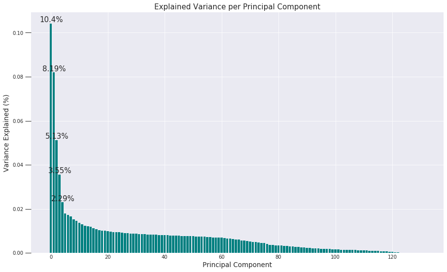

```python
# Investigate the variance accounted for by each principal component.
def scree_plot(pca):
    '''
    Creates a scree plot associated with the principal components
    INPUT: pca - the result of instantian of PCA in scikit learn
    OUTPUT: none
    '''
    sns.set_style("darkgrid")
    num_components = len(pca.explained_variance_ratio_)
    ind = np.arange(num_components)
    vals = pca.explained_variance_ratio_

    plt.figure(figsize=(15,9))
    ax = plt.subplot(111)
    plt.style.use("ggplot")

    cumvals = np.cumsum(vals)
    ax.bar(ind, vals,color='teal')
    for i in range(0,ind[5]):
        ax.annotate(r"%s%%" % ((str(vals[i]*100)[:4])), (ind[i]+0.2,vals[i]), va='bottom',ha='center',fontsize=15)

    ax.xaxis.set_tick_params(width=0)
    ax.yaxis.set_tick_params(width=1,length=12)

    ax.set_xlabel("Principal Component",fontsize=13.5)
    ax.set_ylabel("Variance Explained (%)",fontsize=13.5)
    plt.title("Explained Variance per Principal Component",fontsize=15)

    plt.show()


scree_plot(pca)
```